# tmap

### Kod z użyciem wielu warstw

W niektórych przypadkach pojedyncza warstwa wizualizacji jest wystarczająca, jednak w analizach przestrzennych często konieczne jest łączenie kilku warstw w celu pełniejszego przedstawienia danych.

Biblioteka tmap umożliwia łączenie wielu warstw wizualizacji, co pozwala na tworzenie bardziej złożonych map.

Oprócz podstawowych typów reprezentacji danych dostępne są również warstwy pomocnicze i kartograficzne, m.in.:

- `tm_text()` - dodawanie etykiet tekstowych do obiektów przestrzennych
- `tm_bubbles()` - wizualizacja punktów z wykorzystaniem wielkości symboli
- `tm_borders()` - niezależne kontrolowanie obramowania obiektów
- `tm_grid()` - dodanie siatki współrzędnych
- `tm_compass()` oraz `tm_scalebar()` - elementy kartograficzne (strzałka północy i skala mapy)
- `tm_layout()` - dostosowywanie ogólnego wyglądu mapy (m.in. tła, legendy, tytułu, ramek, marginesów oraz rozmieszczenia elementów kartograficznych)

W niektórych przykładach wykres z jedną warstwą wizualizacji jest wystarczający, ale w niektóych sytuacjach jest on niewystarczający. Jest na to rozwiązanie, w postaci skorzystania z możliwości tworzenia wielu warst wizualizacji.

```
── tmap v3 code detected ───────────────────────────────────────────────────────
```

[output not shown]

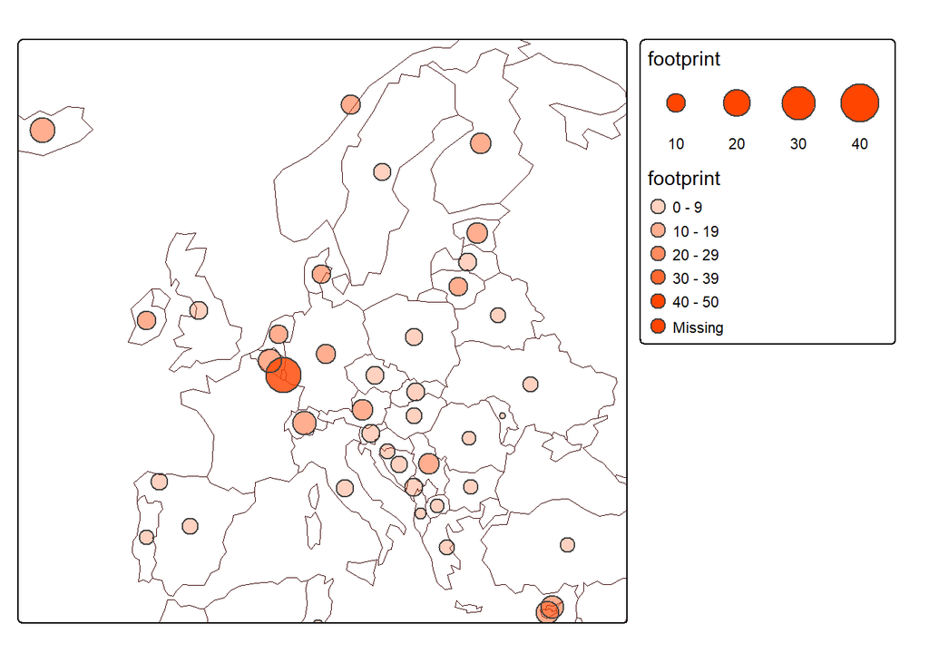

```r
tm_shape(
  World,
  bbox = c(xmin = -20, ymin = 35, xmax = 40, ymax = 70)
) +
  tm_borders(col = "#3A0000", lwd = 0.5) +
  tm_bubbles(size = "footprint", alpha = "footprint", col = "orangered", scale = 2)
```

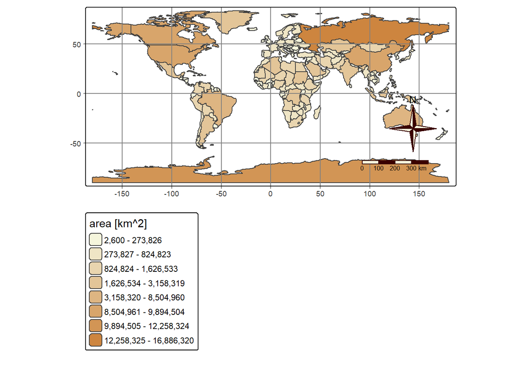

```r
tm_shape(World) +
  tm_polygons(
    fill = "area",
    fill.scale = tm_scale_intervals(
      n = 8,
      style = "jenks",
      values = c("beige", "peru")
    )
  ) +
  tm_grid() +
  tm_compass(
  type = "4star",
  color.light = "beige",
  color.dark = "#3A0000"
  ) +
  tm_scalebar(
    color.light = "beige",
    color.dark = "#3A0000")
```

### Kod z użyciem wielu zbiorów danych

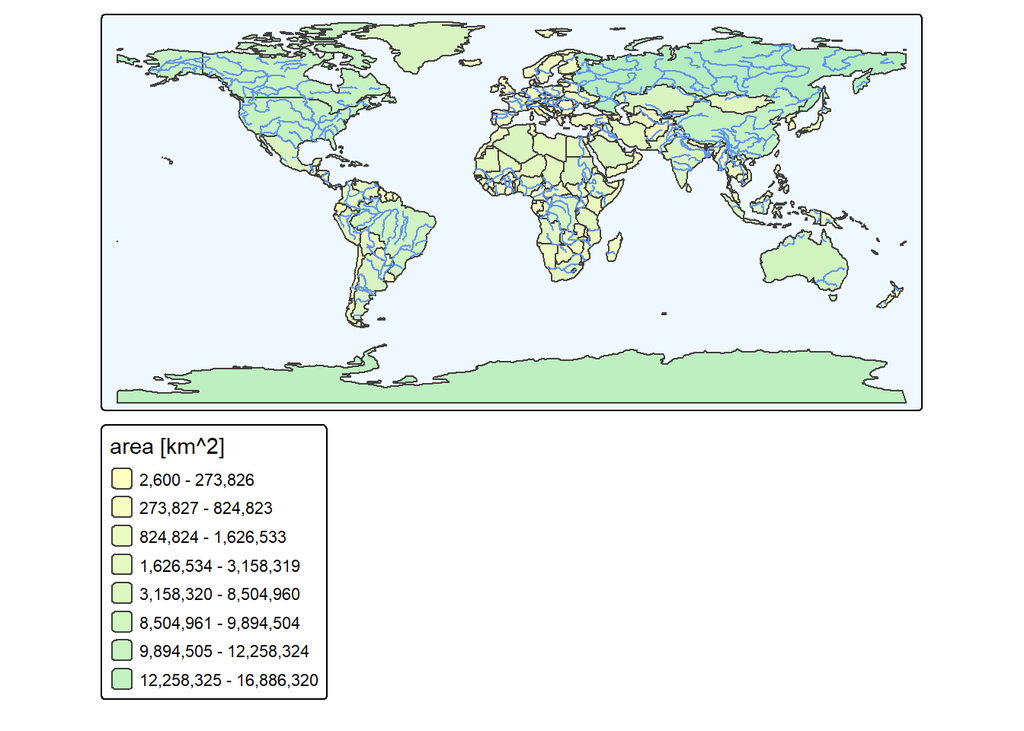

```r
tm_shape(World) +
    tm_polygons(
    fill = "area",
    fill_alpha = 0.25,
    fill.scale = tm_scale_intervals(
      n = 8,
      style = "jenks",
      values = c("yellow", "green3")
    )
  ) +
  tm_layout(bg.color = "aliceblue") +

tm_shape(World_rivers) +
  tm_lines(col = "cornflowerblue")
```

## mapy interaktywne

Biblioteka tmap oferuje dwa główne tryby pracy.

Domyślny tryb `tmap_mode("plot")` służy do tworzenia statycznych map przeznaczonych do wyświetlania w dokumentach, raportach i publikacjach. Z kolei tryb `tmap_mode("view")` umożliwia generowanie map interaktywnych, pozwalających na przybliżanie, przesuwanie oraz wyświetlanie dodatkowych informacji o obiektach przestrzennych.

```r
#Przywrócenie trybu statycznego
#Jeżeli tryb nie został wcześniej zmieniony, polecenie nie wpłynie na wynik.
tmap_mode("plot")
```

```
ℹ tmap modes "plot" - "view"
ℹ toggle with `tmap::ttm()`
```

```r
#Włączenie trybu interaktywnego
#Od tego momentu wszystkie nowo renderowane mapy będą tworzone
  #jako mapy interaktywne, dopóki tryb nie zostanie ponownie zmieniony.
tmap_mode("view")
```

```
ℹ tmap modes "plot" - "view"
```

### Minimalna mapa interaktywna

```r
tm_shape(World) +
  tm_polygons()
```

[interactive chart not shown]